# Cocoa Percentage in Chocolate

Sheli Feigin, Daniel Yohan

2022-05-29

## Background

Who doesn’t like chocolate?

We very much do, and believe (almost) everyone too. Therefore, we find that the correct questions should be about preferences people have regarding chocolate. Specifically - the cocoa percentage they contain.

In this markdown, we’ll analyze the chart from the following site: http://flavorsofcacao.com/chocolate_database.html

## Goals

In our research we’ll focus on 2 main questions:

1. Can we assume there’s a linear regression between the cocoa percentage (as an independent variable), number of ingredients (as “dummies”) and the chocolate rating (as a dependent variable)?
2. Is there a correlation between the manufactures’ location (in which continent they’re based) and the cocoa percentage?

### Libraries

```r
library(tidyverse)
library(readxl)
library(ggplot2)
```

### Importing the Dataset

```r
cocoa_data <- read_excel("cocoa_data.xlsx")
```

### Early Filtering and Tidying

The data set is extracted from an Excel file, imported from the linked site above. We’ve dropped columns that are irrelevant to our tests: ‘REF’ and ‘Most Memorable Characteristics’. Likewise, we’ve omitted rows with missing data.

```r
drop <- c("REF", "Most Memorable Characteristics")
cocoa_data_clean = cocoa_data[,!(names(cocoa_data) %in% drop)]
cocoa_data_clean <- na.omit(cocoa_data_clean)
```

Some header names had to be changed:

```r
names(cocoa_data_clean)[1] <- 'Company_(Manufacturer)'
names(cocoa_data_clean)[2] <- 'Company_Location'
names(cocoa_data_clean)[3] <- 'Review_Year'
names(cocoa_data_clean)[4] <- 'Bean_Origin'
names(cocoa_data_clean)[5] <- 'Specific_Bean_Origin_and_or_Bar_name'
names(cocoa_data_clean)[6] <- 'Cocoa_percent'
```

## First test

In a significance level of 5%:

Our Null hypothesis is that all of the coefficients equal to 0, which means that we can’t state that there’s a linear connections between any of the variables above.

Our Alternative hypothesis is that at least one coefficients isn’t 0, which means that we can approve that there’s a linear connections between some of the variables.

## Transformation, Modeling and Visualization

### Transformation

We’ve extracted the number of ingredients for each chocolate bar and added it to a new column. Also, the given cocoa percentages had to be converted to actual numbers.

```r
num_ingredients <- cocoa_data_clean$Ingredients
num_ingredients = gsub("-.*", "",num_ingredients)
cocoa_data_clean$Num_Ingredients = num_ingredients
cocoa_data_clean$Cocoa_percent <- 100 * (cocoa_data_clean$Cocoa_percent)
```

### Modeling

Here we’ve created some vectors from the relevant columns as variables for the modeling:

```r
rating <- cocoa_data_clean$Rating
cocoa_percent <- cocoa_data_clean$Cocoa_percent

model <- lm( formula = rating ~ cocoa_percent * num_ingredients, data = cocoa_data_clean)

model %>% summary()
```

```
##
## Call:
## lm(formula = rating ~ cocoa_percent * num_ingredients, data = cocoa_data_clean)
##
## Residuals:
##      Min       1Q   Median       3Q      Max
## -2.05081 -0.27517 -0.00326  0.25419  0.95423
##
## Coefficients: (1 not defined because of singularities)
##                                Estimate Std. Error t value Pr(>|t|)
## (Intercept)                     1.45833    3.77543   0.386    0.699
## cocoa_percent                   0.01500    0.03772   0.398    0.691
## num_ingredients2                2.71451    3.78549   0.717    0.473
## num_ingredients3                2.07254    3.78144   0.548    0.584
## num_ingredients4                2.46423    3.78228   0.652    0.515
## num_ingredients5                2.10778    3.78898   0.556    0.578
## num_ingredients6                0.39167    1.07228   0.365    0.715
## cocoa_percent:num_ingredients2 -0.02824    0.03791  -0.745    0.456
## cocoa_percent:num_ingredients3 -0.01865    0.03783  -0.493    0.622
## cocoa_percent:num_ingredients4 -0.02624    0.03785  -0.693    0.488
## cocoa_percent:num_ingredients5 -0.02206    0.03800  -0.581    0.562
## cocoa_percent:num_ingredients6       NA         NA      NA       NA
##
## Residual standard error: 0.4217 on 2432 degrees of freedom
## Multiple R-squared:  0.03502,    Adjusted R-squared:  0.03105
## F-statistic: 8.826 on 10 and 2432 DF,  p-value: 2.268e-14
```

### Visualization

Let’s get a sense of the (supposedly) connection between the cocoa percentage and the chocolate rating. Then we’ll check the same plot but with only one group of chocolate bars at a time (they differ in the number of ingredients), and see if we could witness something interesting.

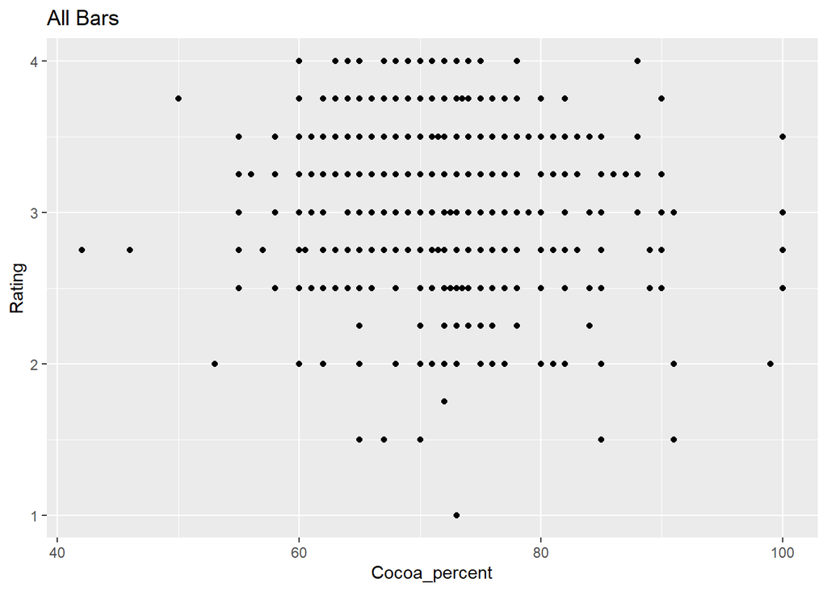

```r
ggplot(cocoa_data_clean, aes(x=Cocoa_percent, y=Rating))+geom_point() + ggtitle("All Bars")
```

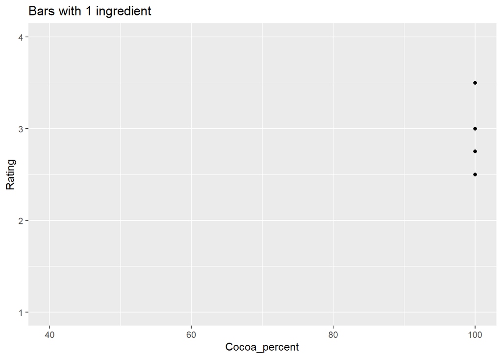

```r
ggplot(subset(cocoa_data_clean, Num_Ingredients == 1), aes(x=Cocoa_percent, y=Rating))+geom_point()+xlim(40, 100)+ylim(1, 4)+ggtitle("Bars with 1 ingredient")
```

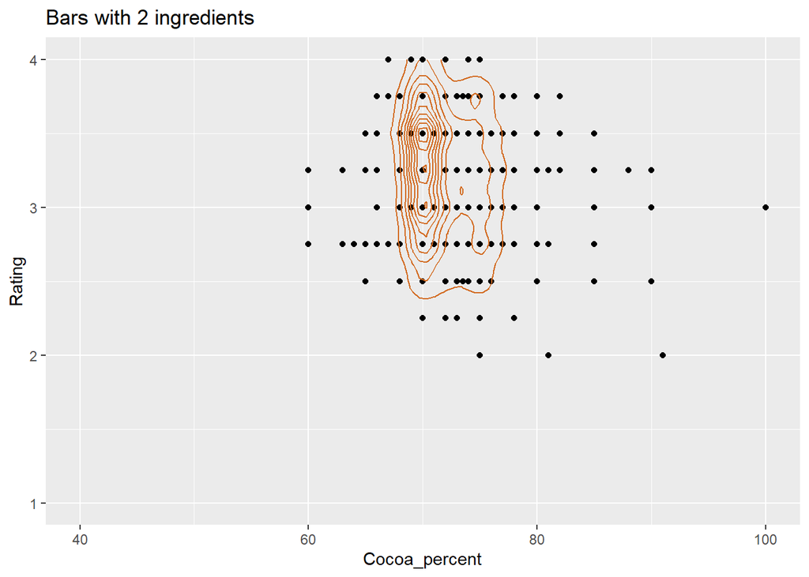

```r
ggplot(subset(cocoa_data_clean, Num_Ingredients == 2), aes(x=Cocoa_percent, y=Rating))+geom_point()+xlim(40, 100)+ylim(1, 4)+ggtitle("Bars with 2 ingredients")+geom_density2d(color="chocolate")
```

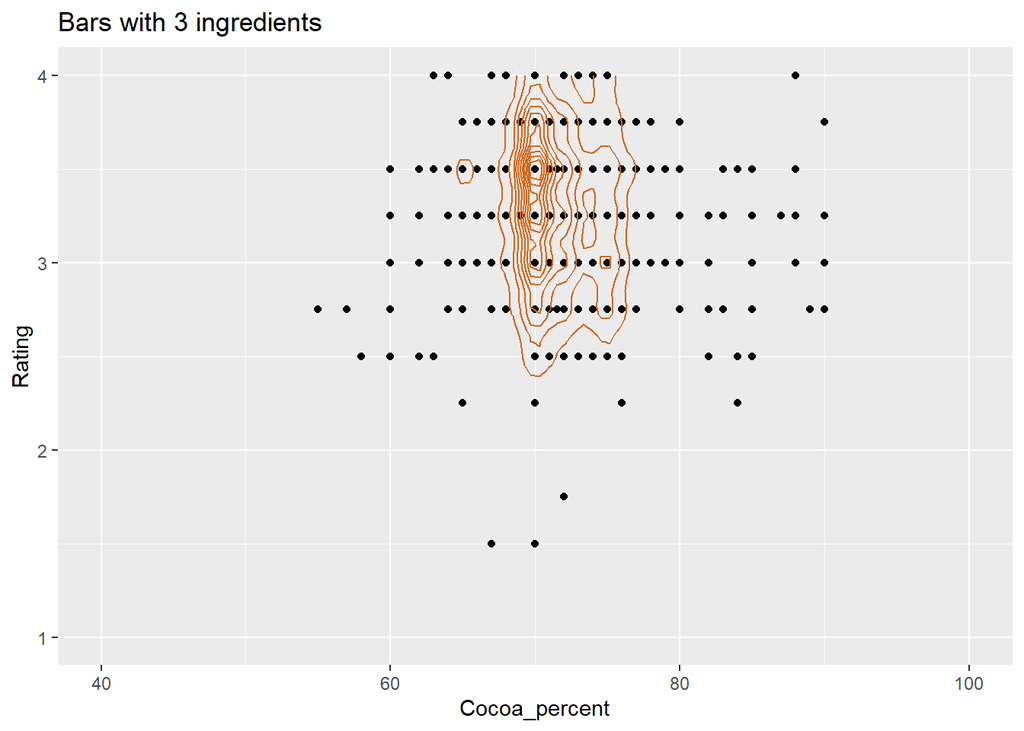

```r
ggplot(subset(cocoa_data_clean, Num_Ingredients == 3), aes(x=Cocoa_percent, y=Rating))+geom_point()+xlim(40, 100)+ylim(1, 4)+ggtitle("Bars with 3 ingredients")+geom_density2d(color="chocolate")
```

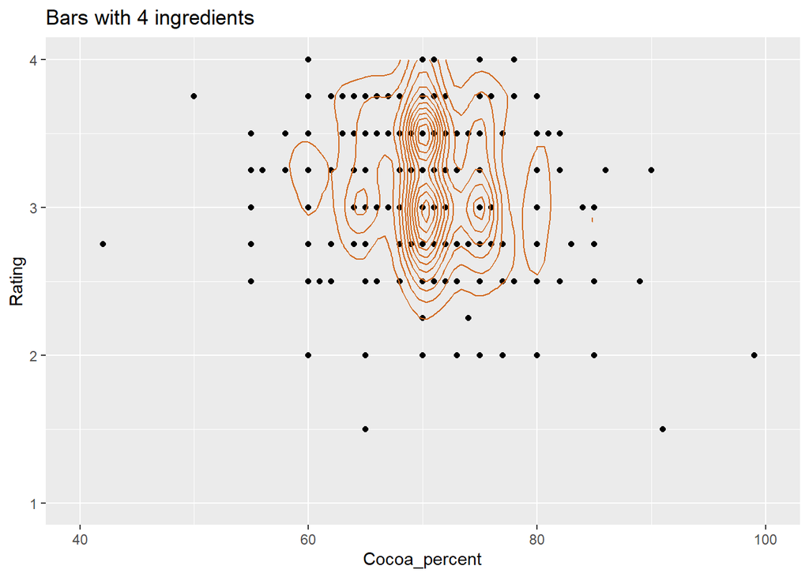

```r
ggplot(subset(cocoa_data_clean, Num_Ingredients == 4), aes(x=Cocoa_percent, y=Rating))+geom_point()+xlim(40, 100)+ylim(1, 4)+ggtitle("Bars with 4 ingredients")+geom_density2d(color="chocolate")
```

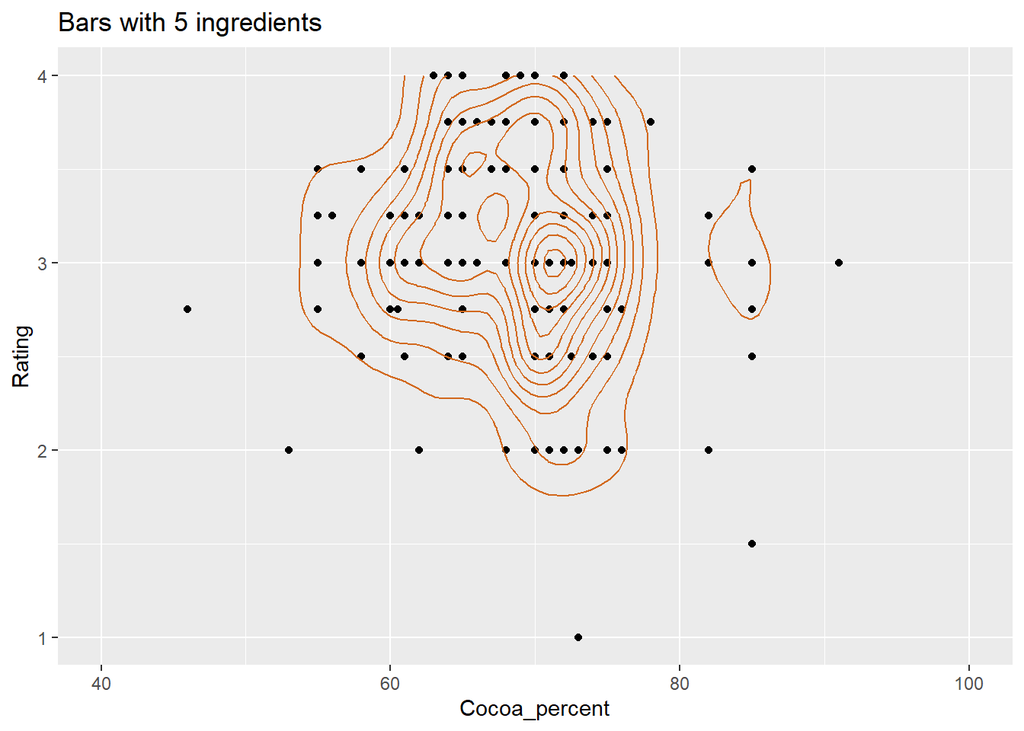

```r
ggplot(subset(cocoa_data_clean, Num_Ingredients == 5), aes(x=Cocoa_percent, y=Rating))+geom_point()+xlim(40, 100)+ylim(1, 4)+ggtitle("Bars with 5 ingredients")+geom_density2d(color="chocolate")
```

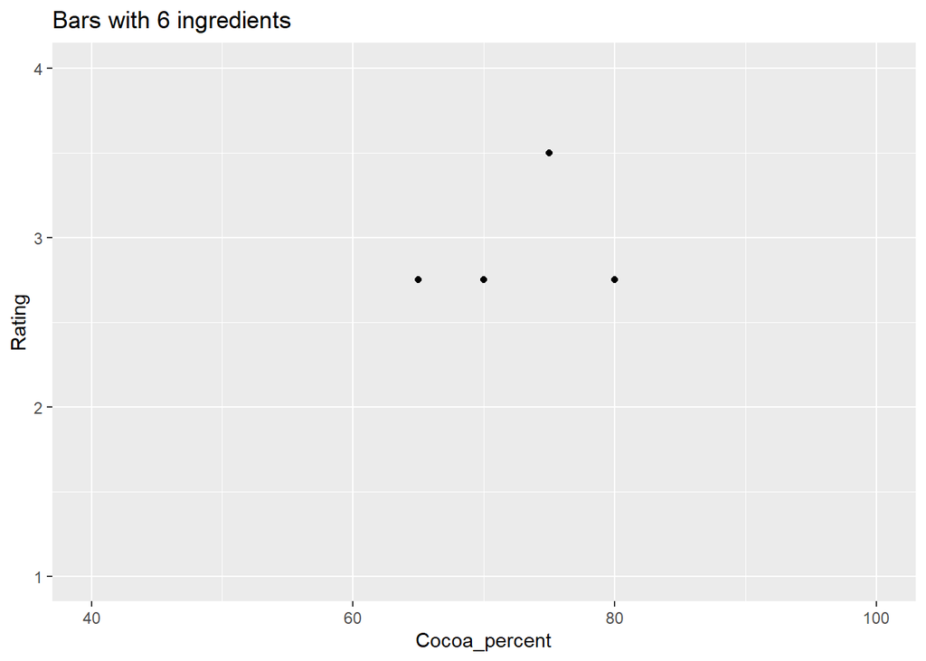

```r
ggplot(subset(cocoa_data_clean, Num_Ingredients == 6), aes(x=Cocoa_percent, y=Rating))+geom_point()+xlim(40, 100)+ylim(1, 4)+ggtitle("Bars with 6 ingredients")
```

The plot for bars with 1 ingredient is prominent since they don’t have many occurrences, and only contains cocoa - which obviously makes them 100% cocoa.

The plot for bars with 6 ingredients shows they neither have many observations in the data set.

From the rest of the plots we understand that most of the bars ratings are greater then 2. Also, based on the density contour, we can roughly see that as the number of ingredients in chocolate bars rise - the scatter become greater. Maybe a variety of ingredients make the cocoa percent a less dominant factor for the taste rating.

Now back to our test - in the following chunk we’ll examine if homoscedasticity exists in our model.

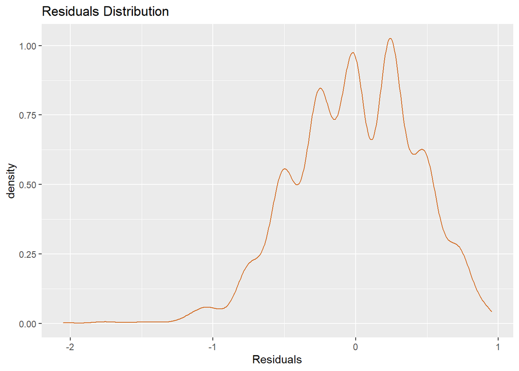

```r
res <- model$residuals
fit <- model$fitted.values
res_table= tibble(res,fit)

ggplot(res_table,aes(x=res)) + geom_density(color="chocolate") + xlab("Residuals") + ggtitle("Residuals Distribution")
```

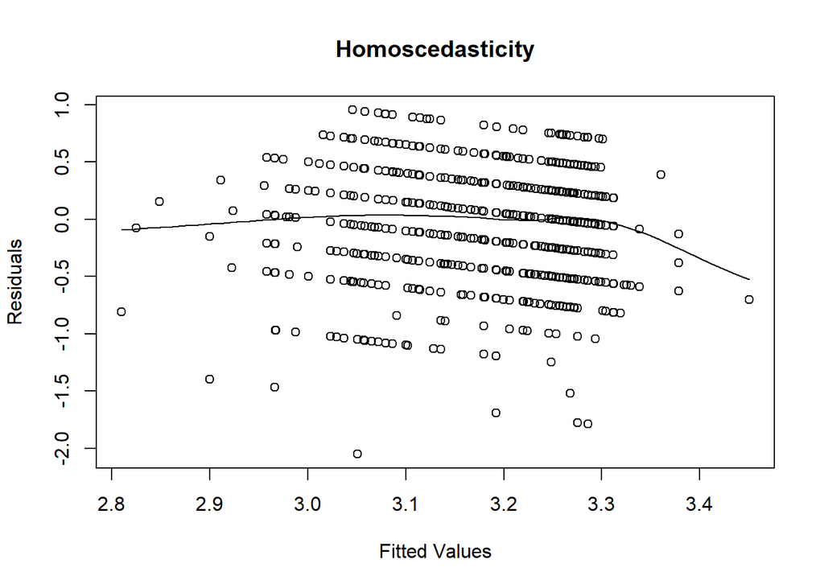

```r
scatter.smooth(x=fit, y=res, main="Homoscedasticity", xlab = "Fitted Values", ylab = "Residuals")
```

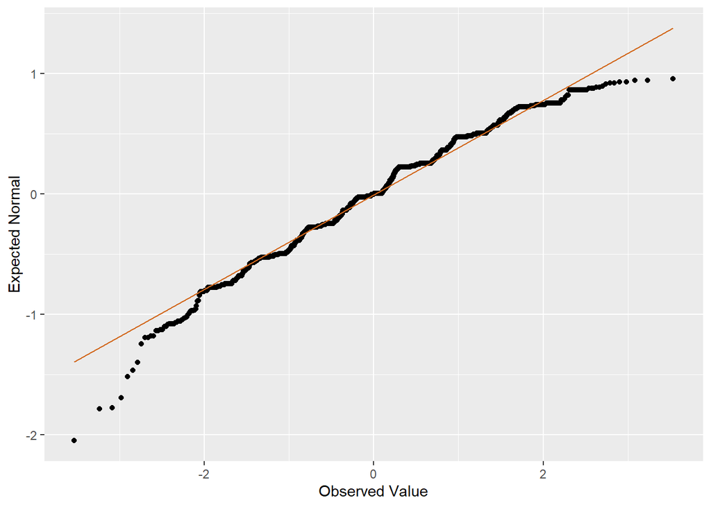

```r
ggplot(res_table, aes(sample=res)) + geom_qq() + geom_qq_line(color="chocolate") + xlab("Observed Value") + ylab("Expected Normal")
```

We notice from the second plot that the variance is not quite consistent along the fitted values. Moreover, we can see from the third that the residuals can’t be found on the line - which means they don’t distribute normally. Consequently, we infer there’s no homoscedasticity in our model. In any case we’ll conclude the test as we could assume homoscedasticity.